# Analiza populacji psów w Zurychu w latach 2015-2023

Marta Dziel

Maj 2023

## 1. Dane źródłowe

Do poniższej analizy wykorzystana została baza danych udostępniona publicznie przez Urząd Miasta Zurych pod linkiem

https://data.stadt-zuerich.ch/dataset/sid_stapo_hundebestand_od1001

## 2. Populacja psów w Zurychu - zmiany w latach 2015 - 2023

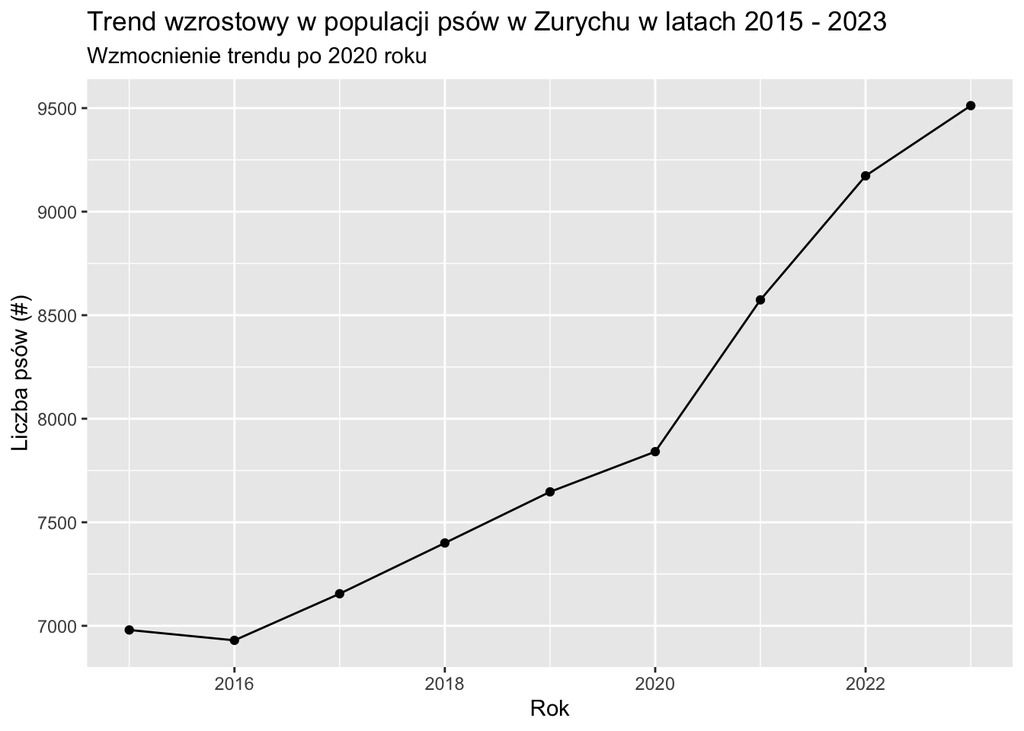

2. Wykres 1

Na powyższym wykresie widać trend wzrostowy w populacji psów w Zurychu - wartości rosły już między latami 2016 - 2019, natomiast widać znaczny wzrost tej tendencji od roku 2020. Prawdopodobnie jest to spowodowane zmianą trybu życia wywołaną przez pandemię.

W latach 2022-2023 widać w dalszym ciągu tendencję wzrostową, jednakże nie jest ona aż tak silna jak w dwóch poprzednich latach - co może wskazywać na np. konieczność powrotu pracowników do biura, co ma realny wpływ na decyzje o posiadaniu psa.

## 3. Populacja psów w Zurychu w podziale na psy rasowe vs psy rasy mieszanej

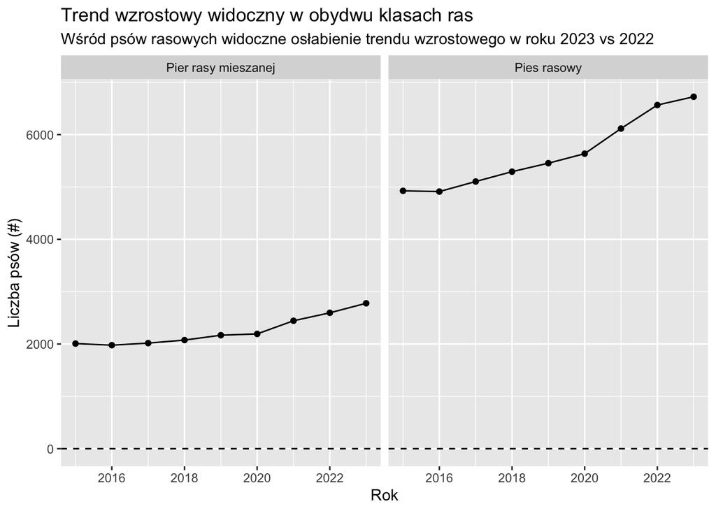

Wykres 2

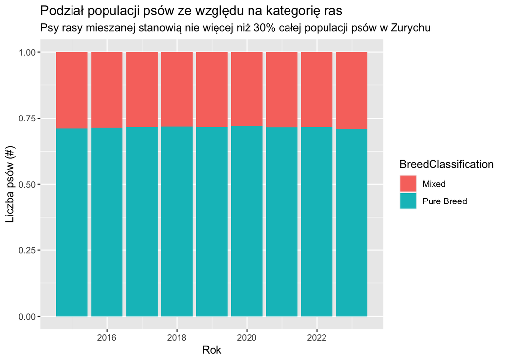

Wykres 3

Analizując obydwa powyższe zestawienia można zauważyć, że:

1. Kategoria psów rasowych jest zdecydowanie liczniejsza niż kategoria psów rasy mieszanej
2. Widać trend wzrostowy w liczbie posiadanych psów w obydwu kategoriach; w obydwu kategoriach trend ten został wzmocniony w latach 2020 - 2023

## 4. Populacja psów w Zurychu w podziale na grupy wiekowe właścicieli - w okresie 2015 - 2023

### 4.1 Analiza trendu wśród wszystkich grup wiekowych zawartych w bazie danych.

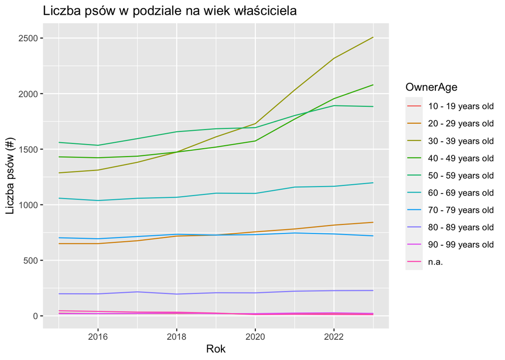

Wykres 4

Patrząc na powyższy wykres nasuwają się trzy wnioski:

1. Ze względu na dużą liczebność grup wiekowych, wykres nie jest czytelny
2. Cztery kategorie wiekowe (10-19 lat, 80-89 lat, 90-99 lat, n.a.) posiadają bardzo niską liczbę rekordów i dla zwiększenia czytelności danych można byłoby je wykluczyć, bądź skonsolidować w większe grupy
3. W trzech grupach wiekowych (30-39 lat, 40-49 lat, 50-59 lat) widać największą liczebność psów, jak również najsilniejszy trend wzrostowy w latach 2020-2023

### 4.2 Analiza wyników w poszczególnych kategoriach wiekowych

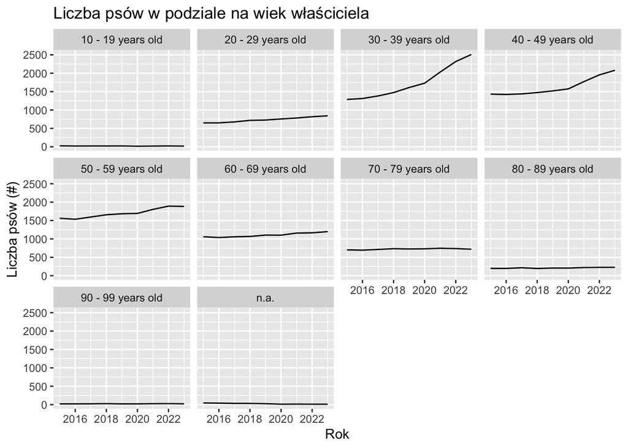

Wykres 5

Patrząc na powyższy wykres można się zacząć zastanawiać nad zasadnością właczania poniższych grup do analizy:

- 10 - 19 lat
- 80 - 89 lat
- 90 - 90 lat
- n.a.

Z pewnością z analizy można wyłączyć ostatnią kategorię - liczebość jest bardzo niska i są to brakujące dane - zostawienie ich w analizie nie wnosi wartości.

Pozostaje pytanie - co zrobić w przypadku pozostałych grup?

#### 4.2.1 Przedział wiekowy: 10 - 19 lat

Liczba psów posiadanych przez grupę wiekową 10 - 19 lat

| Year | DogSum |
| --- | --- |
| 2015 | 24 |
| 2016 | 20 |
| 2017 | 21 |
| 2018 | 21 |
| 2019 | 22 |
| 2020 | 15 |
| 2021 | 19 |
| 2022 | 22 |
| 2023 | 18 |

Liczebność grupy jest bardzo mała (w 2023 stanowi ona jedynie 0.19% całej populacji psów). Natomiast robiąc wyrywkowe testy poprzez sprawdzanie wyników dla konkretnego właściciela (OwnerID) można zauważyć, że często z biegiem lat dany właściciel przechodzi do następnej grupy wiekowej - zostało to przedstawione w tabeli poniżej:

Tabela wyników dla właściciela 120846 wyselekcjonowanego z grupy wiekowej 10-19 lat

| Year | OwnerID | OwnerAge | OwnerGender | District | Area | BreedPrimary | BreedSecondary | BreedClassification | BreedType | DogYear | DogAgeNumber | DogAgeCategory | DogGender | DogColor | DogValues |
| --- | --- | --- | --- | --- | --- | --- | --- | --- | --- | --- | --- | --- | --- | --- | --- |
| 2015 | 120846 | 10- bis 19-Jährige | weiblich | Kreis 11 | Seebach | Malteser | Bolonka Zwetna | Mischling, beide Rassen bekannt | Kleinwüchsig | 2013 | 1 | 1-Jährige | weiblich | tricolor | 1 |
| 2016 | 120846 | 10- bis 19-Jährige | weiblich | Kreis 11 | Seebach | Malteser | Bolonka Zwetna | Mischling, beide Rassen bekannt | Kleinwüchsig | 2013 | 2 | 2-Jährige | weiblich | tricolor | 1 |
| 2017 | 120846 | 10- bis 19-Jährige | weiblich | Kreis 11 | Seebach | Malteser | Bolonka Zwetna | Mischling, beide Rassen bekannt | Kleinwüchsig | 2013 | 3 | 3-Jährige | weiblich | tricolor | 1 |
| 2018 | 120846 | 10- bis 19-Jährige | weiblich | Kreis 11 | Seebach | Malteser | Bolonka Zwetna | Mischling, beide Rassen bekannt | Kleinwüchsig | 2013 | 4 | 4-Jährige | weiblich | tricolor | 1 |
| 2019 | 120846 | 20- bis 29-Jährige | weiblich | Kreis 11 | Seebach | Malteser | Bolonka Zwetna | Mischling, beide Rassen bekannt | Kleinwüchsig | 2013 | 5 | 5-Jährige | weiblich | tricolor | 1 |
| 2020 | 120846 | 20- bis 29-Jährige | weiblich | Kreis 11 | Seebach | Malteser | Bolonka Zwetna | Mischling, beide Rassen bekannt | Kleinwüchsig | 2013 | 6 | 6-Jährige | weiblich | tricolor | 1 |
| 2021 | 120846 | 20- bis 29-Jährige | weiblich | Kreis 11 | Seebach | Malteser | Bolonka Zwetna | Mischling, beide Rassen bekannt | Kleinwüchsig | 2013 | 7 | 7-Jährige | weiblich | tricolor | 1 |
| 2022 | 120846 | 20- bis 29-Jährige | weiblich | Kreis 11 | Seebach | Malteser | Bolonka Zwetna | Mischling, beide Rassen bekannt | Kleinwüchsig | 2013 | 8 | 8-Jährige | weiblich | tricolor | 1 |
| 2023 | 120846 | 20- bis 29-Jährige | weiblich | Kreis 11 | Seebach | Malteser | Bolonka Zwetna | Mischling, beide Rassen bekannt | Kleinwüchsig | 2013 | 9 | 9-Jährige | weiblich | tricolor | 1 |

Na powyższym przykładzie widzimy, że wybrany właściciel zarejestrował psa w roku 2015 i od tamtej pory w dalszym ciągu jest jego właścicielem. Widzimy, że dalej jest to ten sam pies (np. sprawdzając rasę, kolor, płeć psa), ale zmienia się jego wiek - tak samo jak zmienia się wiek właściciela, który w 2019 przeszedł z grupy 10-19 lat do grupy 20-29lat. Dlatego też połączenie tych grup wiekowych wydaje się być optymalnym rozwiązaniem pod kątem dalszej analizy.

#### 4.2.2 Przedział wiekowy: 80 - 89 lat oraz 90 - 99 lat

Liczba psów posiadanych przez grupę wiekową 80 - 89 lat

| Year | DogSum |
| --- | --- |
| 2015 | 199 |
| 2016 | 198 |
| 2017 | 216 |
| 2018 | 196 |
| 2019 | 208 |
| 2020 | 207 |
| 2021 | 222 |
| 2022 | 227 |
| 2023 | 228 |

Liczba psów posiadanych przez grupę wiekową 90 - 99 lat

| Year | DogSum |
| --- | --- |
| 2015 | 20 |
| 2016 | 20 |
| 2017 | 22 |
| 2018 | 26 |
| 2019 | 20 |
| 2020 | 20 |
| 2021 | 25 |
| 2022 | 27 |
| 2023 | 22 |

Obydwie grupy ponownie są stosunkowo niewielkie w skali całej populacji psów w Zurychu:

- 80 - 89 lat stanowi 2.4% całej populacji psów
- 90 - 99 lat stanowi 0.2% całej populacji psów

Ponownie, występuje tutaj pytanie - czy wyłączyć te dwie grupy z analizy, czy może skonsolidować je w jedną większą grupę?

Aby móc odpowiedzieć na to pytanie warto zastanowić się - czy są to grupy, które aktywnie nabywają nowe psy, czy może są to grupy “bierne”, gdzie obecne liczebności wynikają z tego, że te osoby weszły w posiadanie psa/psów będąc w niższej grupie wiekowej?

#### 4.2.3 Podsumowanie - dane dla ostatecznych grup wiekowych

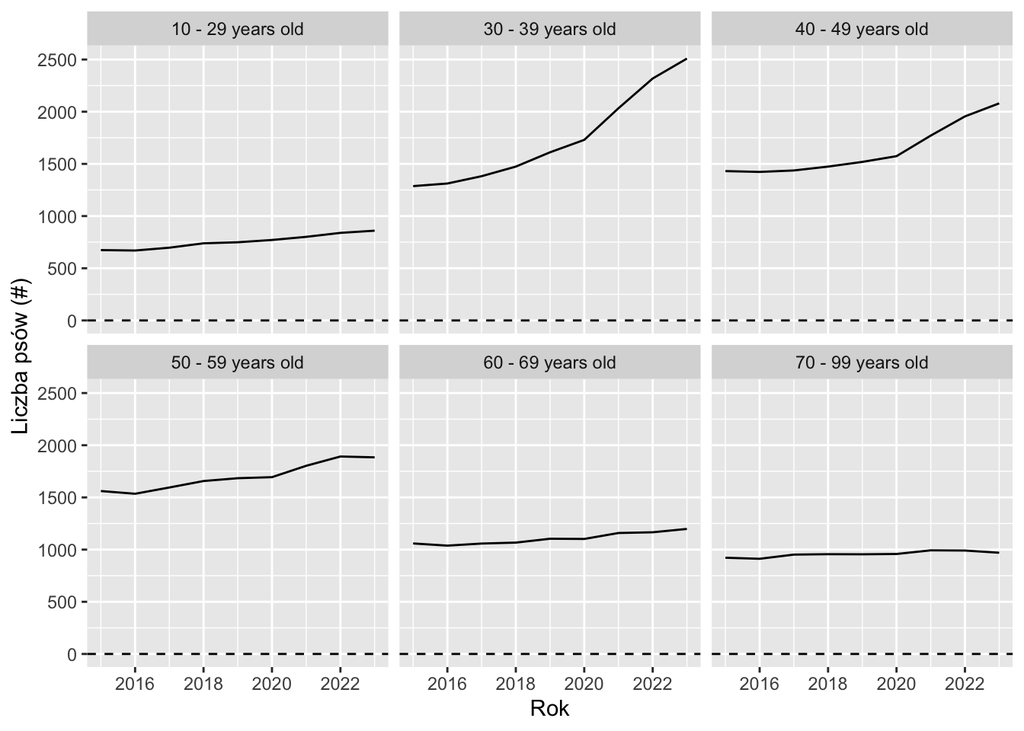

Wykres 3

Wnioski:

1. W każdej z analizowanych grup wiekowych widoczny jest trend wzrostowy w liczbie posiadanych psów w okresie 2015 - 2023
2. Grupy wiekowe: 30-39 lat, 40-49 lat, 50-59 lat są najliczniejszymi grupami (w ciągu całego badanego okresu)
3. W grupach wymienionych w pkt. 2. widoczne jest znaczne wzmocnienie trendu wzrostowego w latach 2020-2022
4. W grupach wymienionych w pkt. 2. widoczne jest osłabienie trendu wzrostowego w latach 2022-2023

## 5. Populacja psów w Zurychu w podziale na wiek psów - w okresie 2015 - 2023

Istnieje aż 23 kategorii wiekowych psów. Dla zwiększenia przejrzystości analizy, dane zostały pogrupowane w 5 kategorii wiekowych

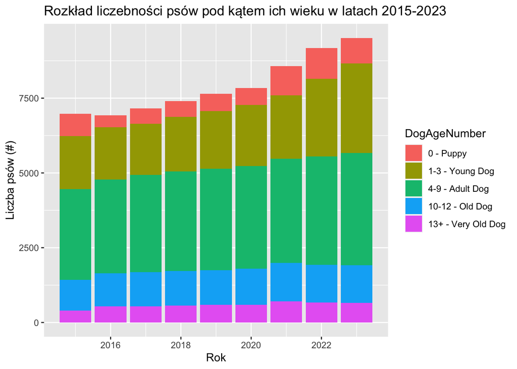

Wykres 3

Analizując rozkład liczebności psów pod kątem ich wieku widać, że najwięcej psów jest w przedziale wiekowym 4-9 lat (pies dorosły) oraz 1-3 (młody pies). W latach 2021 oraz 2022 widac było też znaczny wzrost liczby szczeniaków (poniżej 1 roku). Taki rozkład wieku wśród populacji psów w Zurychu może być informacją istotną dla osób, które zastanawiają się nad prowadzeniem biznesu związanego z psami - szkolenia, fryzjer, sklepy z akcesoriami, itd.

## 5. Populacja psów w Zurychu w podziale na rasy psów - w okresie 2015 - 2023

W rejestrze psów w Zurychu widnieje 394 ras psów - z tego powodu, do dalszej analizy wybranych zostało top 10 ras psów zarejestrowanych w 2023 roku (Sprawdzane pod kątem kryterium “Primary Breed” która mówi o do minującej rasie - co oznacza, że analiza zostanie przeprowadzona zarówno na psach rasowych jak i o rasie mieszanej).

[figure not shown]

Wykres 3

### 6. Analiza liczebności szczeniaków w latach 2015-2023

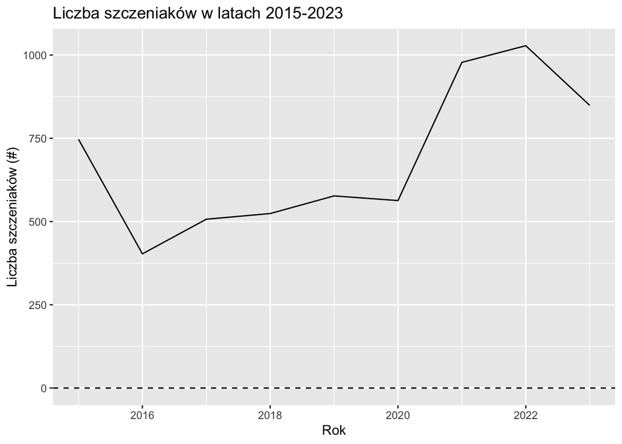

Wykres 3

[figure not shown]

Wykres 3

[figure not shown]

Wykres 3

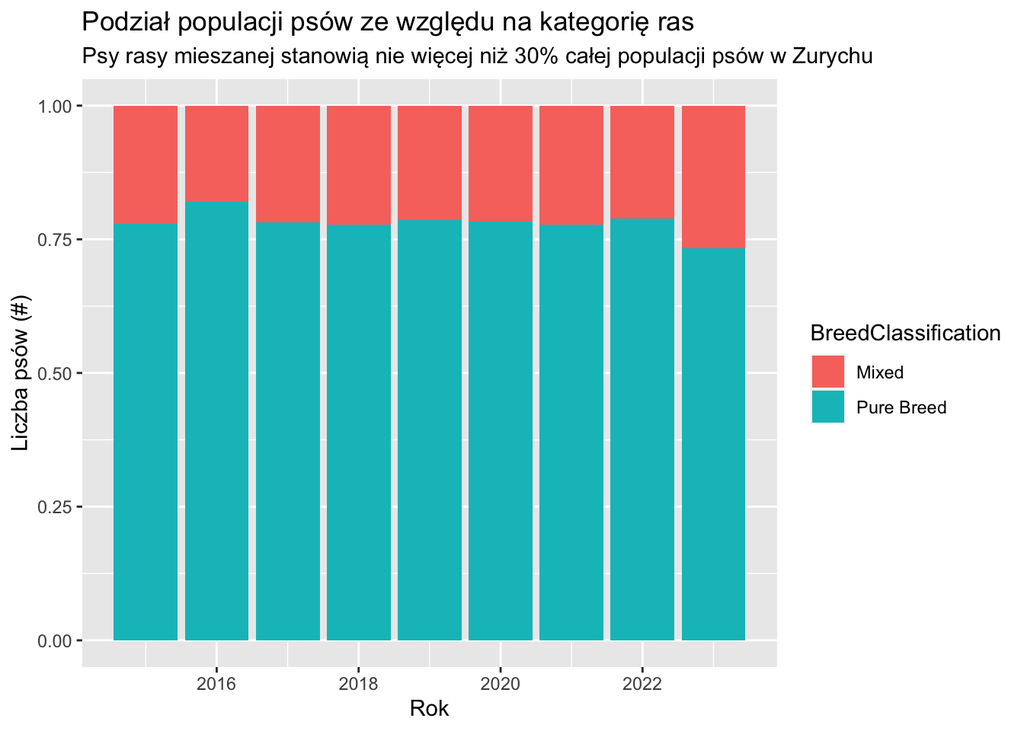

Wykres 3

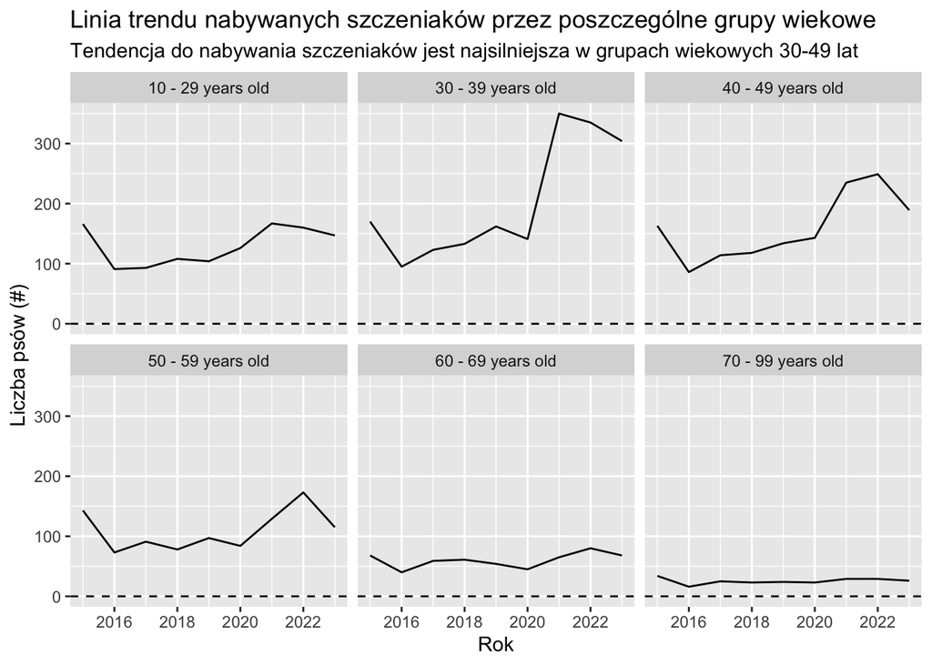

Wykres 3

[figure not shown]

Wykres 3

Spojrzenie na trend w ilości szczeniaków (tym razem bez rozróżnienia na to, czy jest to pies rasowy, czy rasy mieszanej) zdaje się potwierdzać tezę o wzroście liczebności psów ze względu na pandemię. Należy jednocześnie pamiętać, że analizowane są dane psów zarejestrowanych w mieście Zurych - nie można zatem wnioskować, czy w tym czasie znacznie zwiększyła się dostępność (oraz liczebność) szczeniąt w odpowiedzi na zwiększony popyt (należy pamiętać, że pies to istota żywa i są granice tego w jaki sposób podaż może odpowiedzieć na popyt), czy może zmieniła się proporcja jeśli chodzi o nabywców na korzyść mieszkańców miasta Zurych.